# habanalysis

2024-04-02

Subsets of Tasman/Marlborough

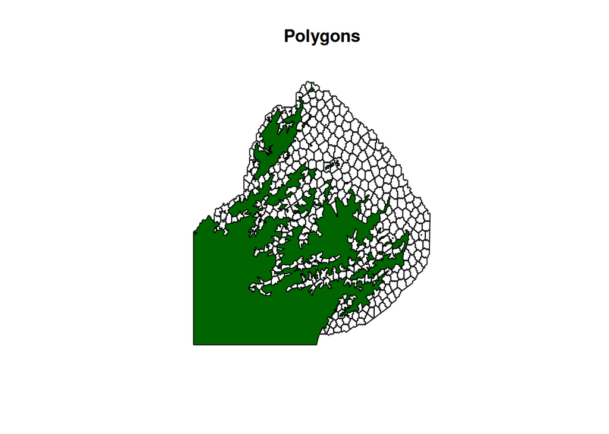

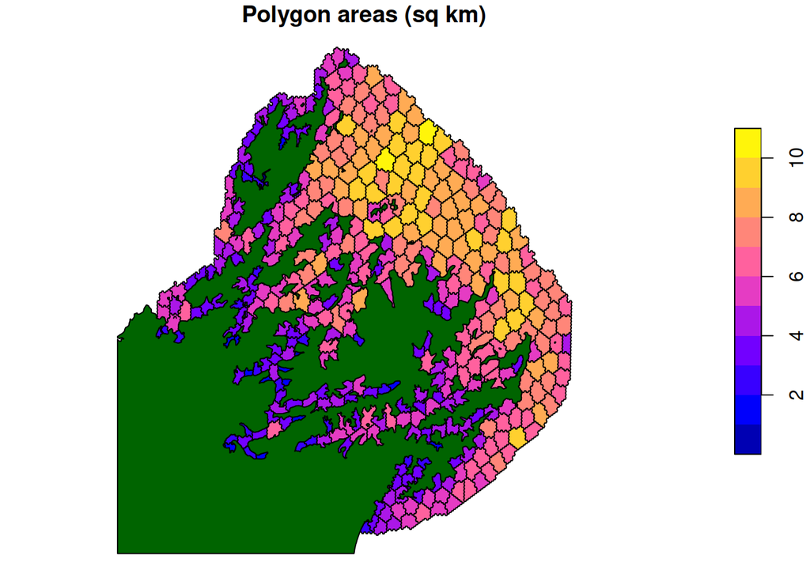

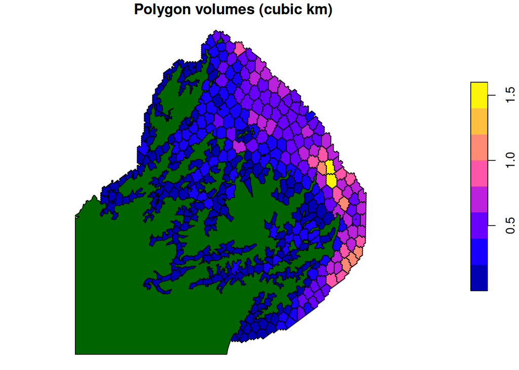

Locations

Detections from 1 Jan 2018 onwards

```
## [1] 6527
```

```
## [1] 6372
```

Need one event per polygon per week - just take the first event for simplicity

```
## [1] 6372
```

```
## [1] 6351
```

```
##
## FALSE  TRUE
##    21  6351
```

```
##
##     FALSE TRUE
##   0     6 5649
##   1    15  702
```

```
## [1] 6351
```

Find number of detections and max observation value per polygon

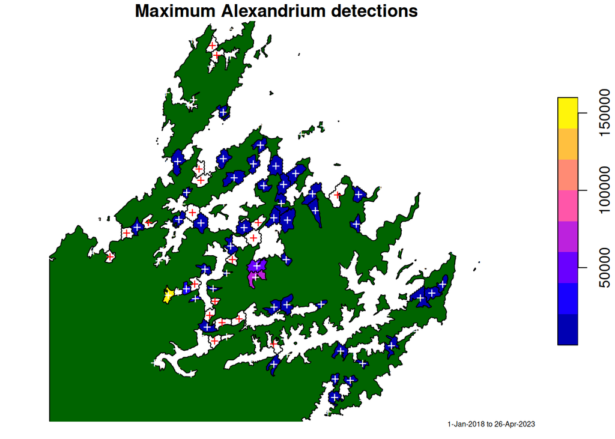

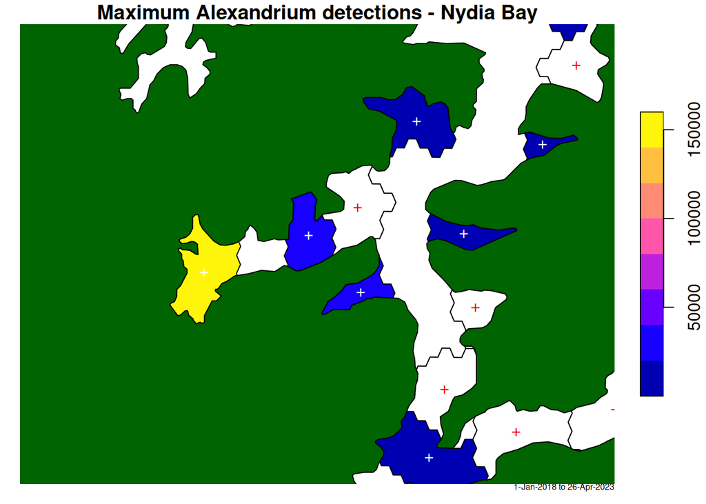

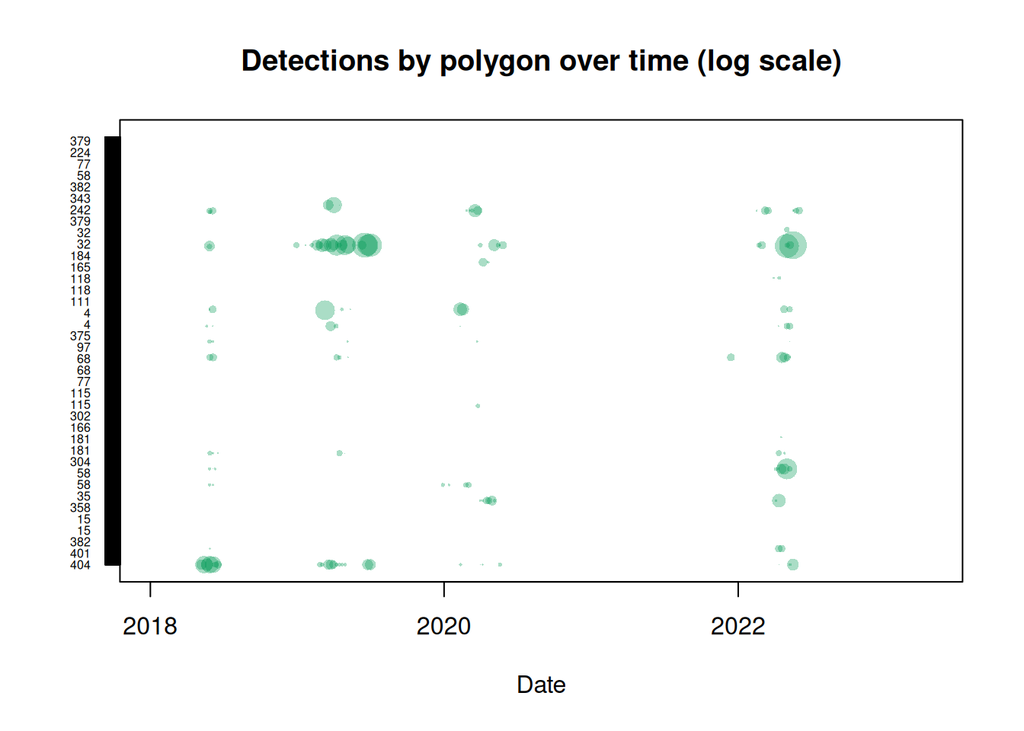

# Connectivity and Migration matrices

In the matrices below the rows are the destination locations ($i=1,\dots,n$) and the columns are the source locations ($j=1,\ldots,n$).

**Notes from Romain**

I am sending you 2 matrices with two different ways of computing the connectivity. Each file has one sheet per release day and each sheet shows the connectivity after 7 days of tracking.

Rows represent the source locations and columns represent the receiving locations (ordered following the sampling stations ID).

In Connectivity_matrices_04_to_07_2018, you will find the connectivity represented as a percentage of the total released at each sampling station, so each row almost add to 1 (some particles are not within a polygon at the end of the run, and therefore they are not counted).

In Migration_matrices_04_to_07_2018, you will find the connectivity normalized per column (sum to 1 per column). This gives you the percentage of the contribution of each source location to a receiving location.

**RA:** We reverse the rows/columns when reading in: connectivities ($P$) should then have unit column sums, and migrations ($Q$) have unit row sums

Note range=cell_cols(1:408) specifies to read 408 columns - otherwise leading blank columns get dropped

```
##      20180402 20180409 20180416 20180423 20180430 20180507 20180514 20180521
## [1,]        0        0        0        0        0        0        0        0
## [2,]        0        0        0        0        0        0        0        0
##      20180528 20180604 20180611 20180618
## [1,]        0        0        0        0
## [2,]        0        0        0        0
```

Correctly identifies the columns as source polygons, rows as destinations

```
## [1] 408 408
```

```
## [1] 0.2671909 1.8654077
```

```
## [1] 0 1
```

```
##
## TRUE
##  408
```

```
##
## FALSE  TRUE
##     1   407
```

```
## Simple feature collection with 1 feature and 8 fields
## Geometry type: MULTIPOLYGON
## Dimension:     XY
## Bounding box:  xmin: 1669076 ymin: 5428156 xmax: 1671386 ymax: 5430105
## Projected CRS: NZGD2000 / New Zealand Transverse Mercator 2000
##     id    left       top    right    bottom CLUSTER_ID CLUSTER_SI volume
## 1 8988 173.825 -41.28493 173.8308 -41.28993        195         15      0
##                         geometry
## 1 MULTIPOLYGON (((1670161 542...
```

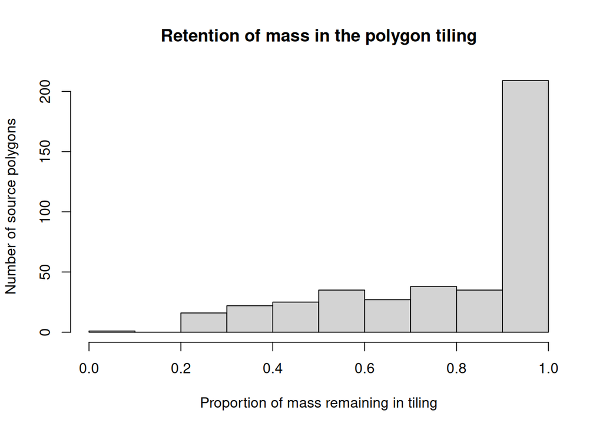

```
## [1] 0 0
```

```
## [1] 0.0000000 0.2469852
```

```
## [1]   6  47  75  86 154 162 190 345 396
```

Plot water residency by polygon

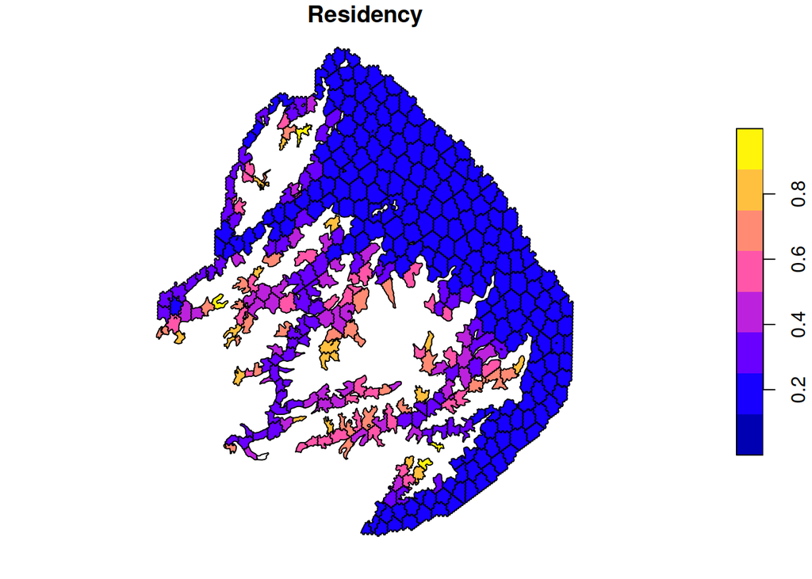

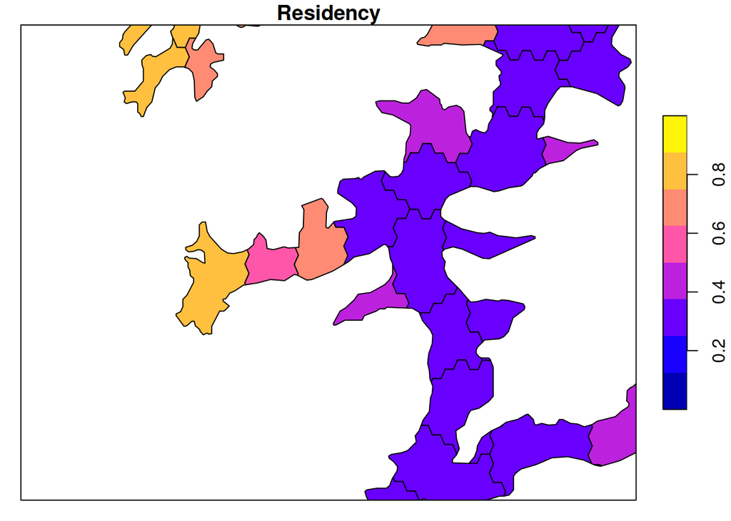

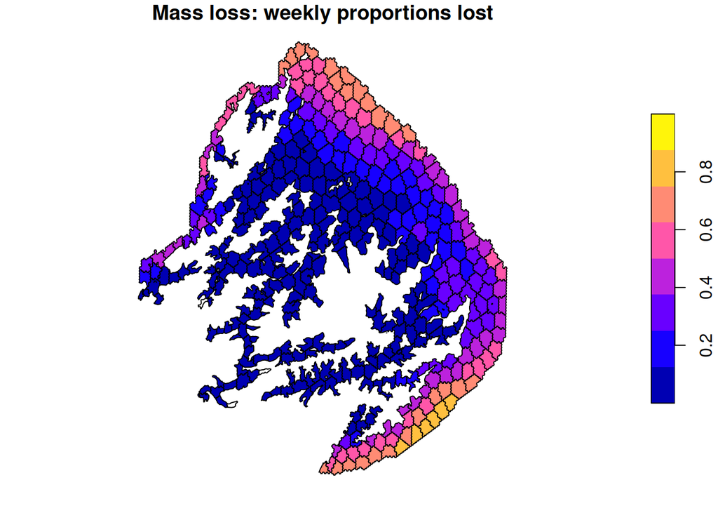

Which polygons are in the Nydia area?

```
## Simple feature collection with 0 features and 9 fields
## Bounding box:  xmin: NA ymin: NA xmax: NA ymax: NA
## Projected CRS: NZGD2000 / New Zealand Transverse Mercator 2000
##  [1] id         left       top        right      bottom     CLUSTER_ID
##  [7] CLUSTER_SI volume     geometry   area
## <0 rows> (or 0-length row.names)
```